# **Problem Statement**

## **Business Context**

Workplace safety in hazardous environments like construction sites and industrial plants is crucial to prevent accidents and injuries. One of the most important safety measures is ensuring workers wear safety helmets, which protect against head injuries from falling objects and machinery. Non-compliance with helmet regulations increases the risk of serious injuries or fatalities, making effective monitoring essential, especially in large-scale operations where manual oversight is prone to errors and inefficiency.

To overcome these challenges, SafeGuard Corp plans to develop an automated image analysis system capable of detecting whether workers are wearing safety helmets. This system will improve safety enforcement, ensuring compliance and reducing the risk of head injuries. By automating helmet monitoring, SafeGuard aims to enhance efficiency, scalability, and accuracy, ultimately fostering a safer work environment while minimizing human error in safety oversight.

## **Objective**

As a data scientist at SafeGuard Corp, you are tasked with developing an image classification model that classifies images into one of two categories:

- **With Helmet:** Workers wearing safety helmets.
- **Without Helmet:** Workers not wearing safety helmets.

## **Data Description**

The dataset consists of **631 images**, equally divided into two categories:

- **With Helmet:** 311 images showing workers wearing helmets.
- **Without Helmet:** 320 images showing workers not wearing helmets.

**Dataset Characteristics:**

- **Variations in Conditions:** Images include diverse environments such as construction sites, factories, and industrial settings, with variations in lighting, angles, and worker postures to simulate real-world conditions.
- **Worker Activities:** Workers are depicted in different actions such as standing, using tools, or moving, ensuring robust model learning for various scenarios.

# **Installing and Importing the Necessary Libraries**

```python
#!pip install tensorflow[and-cuda] numpy==1.25.2 -q
```

[output not shown]

```python
import tensorflow as tf
print("Num GPUs Available:", len(tf.config.list_physical_devices('GPU')))
print(tf.__version__)
```

```
Num GPUs Available: 1
2.19.0
```

**Note:**

- After running the above cell, kindly restart the notebook kernel (for Jupyter Notebook) or runtime (for Google Colab) and run all cells sequentially from the next cell.
- On executing the above line of code, you might see a warning regarding package dependencies. This error message can be ignored as the above code ensures that all necessary libraries and their dependencies are maintained to successfully execute the code in this notebook.

```python
import os
import random
import numpy as np                                                                               # Importing numpy for Matrix Operations
import pandas as pd
import seaborn as sns
import matplotlib.image as mpimg                                                                              # Importing pandas to read CSV files
import matplotlib.pyplot as plt                                                                  # Importting matplotlib for Plotting and visualizing images
import math                                                                                      # Importing math module to perform mathematical operations
import cv2


# Tensorflow modules
import keras
import tensorflow as tf
from tensorflow.keras.preprocessing.image import ImageDataGenerator                              # Importing the ImageDataGenerator for data augmentation
from tensorflow.keras.models import Sequential                                                   # Importing the sequential module to define a sequential model
from tensorflow.keras.layers import Dense,Dropout,Flatten,Conv2D,MaxPooling2D,BatchNormalization # Defining all the layers to build our CNN Model
from tensorflow.keras.optimizers import Adam,SGD                                                 # Importing the optimizers which can be used in our model
from sklearn import preprocessing                                                                # Importing the preprocessing module to preprocess the data
from sklearn.model_selection import train_test_split                                             # Importing train_test_split function to split the data into train and test
from sklearn.metrics import confusion_matrix
from tensorflow.keras.models import Model
from keras.applications.vgg16 import VGG16                                               # Importing confusion_matrix to plot the confusion matrix

# Display images using OpenCV
from google.colab.patches import cv2_imshow

#Imports functions for evaluating the performance of machine learning models
from sklearn.metrics import confusion_matrix, f1_score,accuracy_score, recall_score, precision_score, classification_report
from sklearn.metrics import mean_squared_error as mse                                                 # Importing cv2_imshow from google.patches to display images

# Ignore warnings
import warnings
warnings.filterwarnings('ignore')
```

```python
# Set the seed using keras.utils.set_random_seed. This will set:
# 1) `numpy` seed
# 2) backend random seed
# 3) `python` random seed
tf.keras.utils.set_random_seed(812)

# If using TensorFlow, this will make GPU ops as deterministic as possible,
# but it will affect the overall performance, so be mindful of that.
tf.config.experimental.enable_op_determinism()
```

# **Data Overview**

## Loading the data

```python
from google.colab import drive
drive.mount('/content/drive')
```

```python
# Load the image file of the dataset
rgb_images = np.load('/content/drive/MyDrive/PythonPrograms/ComputerVision/images_proj.npy')

# Load the labels file of the dataset
labels = pd.read_csv('/content/drive/MyDrive/PythonPrograms/ComputerVision/Labels_proj.csv')
```

Let's print the shape of the images and labels

```python
print(rgb_images.shape)
print(labels.shape)
```

```
(631, 200, 200, 3)
(631, 1)
```

There are 631 images of shape 200 x 200 X 3, each image having 3 channels.

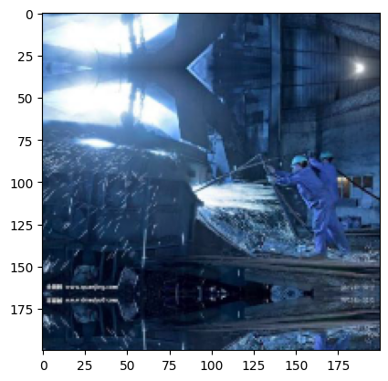

```python
n = 5
plt.imshow(rgb_images[n])
```

# **Exploratory Data Analysis**

```python
# Converting the images from BGR to RGB using cvtColor function of OpenCV
for i in range(len(rgb_images)):
  rgb_images[i] = cv2.cvtColor(rgb_images[i], cv2.COLOR_BGR2RGB)
```

### Plot random images from each of the classes and print their corresponding labels.

This function, `plot_images`, randomly selects images from a dataset and displays them in a 3x4 grid. It retrieves corresponding labels from a dictionary and sets them as titles for each image.

- With Helmet = 1
- Without Helmet = 0

```python
def plot_images(images,labels):
    keys=dict(labels['Label'])
    rows = 3
    cols = 4
    fig = plt.figure(figsize=(10, 8))
    for i in range(cols):
        for j in range(rows):
            random_index = np.random.randint(0, len(labels))
            ax = fig.add_subplot(rows, cols, i * rows + j + 1)
            ax.imshow(images[random_index, :])
            ax.set_title(keys[random_index])
    plt.show()
```

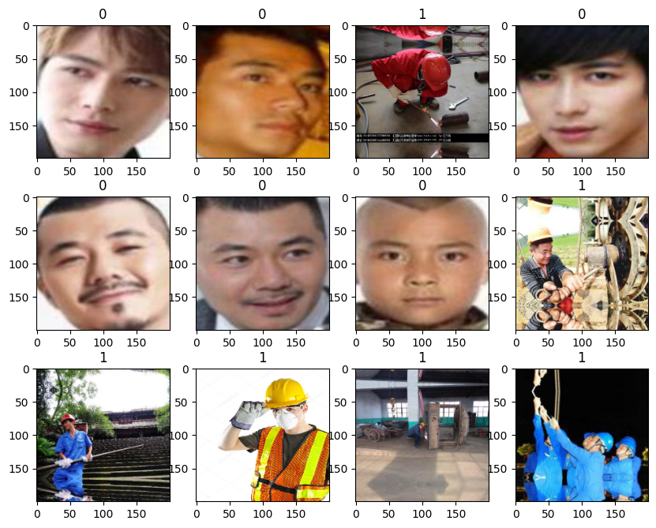

```python
plot_images(rgb_images,labels)
```

## Checking for class imbalance

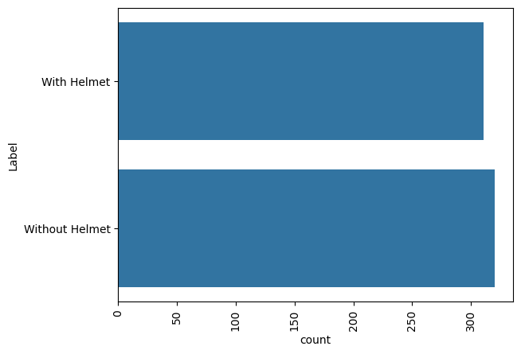

```python
labels['Label'] = labels['Label'].replace({1: 'With Helmet', 0: 'Without Helmet'})
sns.countplot(labels['Label'])
plt.xticks(rotation='vertical');
```

- As you can see from the above plot, the dataset is quite balanced.
- The dataset consists of 631 images, equally divided into two categories:
- With Helmet: 311 images showing workers wearing helmets.
- Without Helmet: 320 images showing workers not wearing helmets.

```python
# Convert labels back to 0 and 1
labels['Label'] = labels['Label'].replace({'With Helmet': 1, 'Without Helmet': 0})
```

# **Data Preprocessing**

We define a function, *`grid_plot`*, to display two images side by side: the original image and its processed version. It helps visually compare the effects of image processing techniques.

**Inputs:**

- `img1`: The original image.
- `img2`: The processed image
- `gray` (optional, default: False): If True, displays the processed image in grayscale.

**Output:**

- The original image displayed on the left and the processed image on the right.

```python
# Function to plot the original and processed images side by side
def grid_plot(img1,img2,gray=False):
    fig, axes = plt.subplots(1, 2, figsize=(12, 5))
    axes[0].imshow(img1)
    axes[0].set_title('Original Image')
    axes[0].axis('off')

    if gray:
      axes[1].imshow(img2,cmap='gray')
    else:
      axes[1].imshow(img2)
    axes[1].set_title('Processed Image')
    axes[1].axis('off')

    plt.show()
```

## Converting images to grayscale

```python
gray_images = []
for i in range(len(rgb_images)):
  gray_images.append(cv2.cvtColor(rgb_images[i], cv2.COLOR_RGB2GRAY))
```

[figure not shown]

```python
# choosing an image
n = 5
# plotting the original and preprocessed image
grid_plot(rgb_images[n],gray_images[n],gray=True)
```

- As expected, the RGB component is removed.
- If the species are not distinguished based on color, then this feature will be highly beneficial as it also reduces computational requirements.

### Splitting the dataset

- As we have less images in our dataset, we will only use 10% of our data for testing, 10% of our data for validation and 80% of our data for training.
- We are using the `train_test_split()` function from scikit-learn. Here, we split the dataset into three parts, train,test and validation.

```python
from sklearn.model_selection import train_test_split
X_train_rgb, X_temp_rgb, y_train_rgb, y_temp_rgb = train_test_split(np.array(rgb_images),labels , test_size=0.2, random_state=42,stratify=labels)
X_val_rgb, X_test_rgb, y_val_rgb, y_test_rgb = train_test_split(X_temp_rgb,y_temp_rgb , test_size=0.5, random_state=42,stratify=y_temp_rgb)
```

```python
print(X_train_rgb.shape,y_train_rgb.shape)
print(X_val_rgb.shape,y_val_rgb.shape)
print(X_test_rgb.shape,y_test_rgb.shape)
```

```
(504, 200, 200, 3) (504, 1)
(63, 200, 200, 3) (63, 1)
(64, 200, 200, 3) (64, 1)
```

## Encoding the target labels

- Convert labels from categories to one hot vectors
- `LabelBinarizer` is a preprocessing utility in `sklearn.preprocessing` that converts categorical labels into a binary (one-hot) representation.
- It is useful for transforming multi-class labels into a format suitable for models that require numerical input.
- `fit_transform()` learns the unique classes from the data and converts labels into a binary format in one step.
- `transform()` converts new data using the already learned classes without refitting.

```python
# Convert labels from names to one hot vectors.
# We have already used encoding methods like onehotencoder and labelencoder earlier so now we will be using a new encoding method called labelBinarizer.
# Labelbinarizer works similar to onehotencoder


from sklearn.preprocessing import LabelBinarizer
enc = LabelBinarizer()
y_train_encoded = enc.fit_transform(y_train_rgb)
y_val_encoded = enc.transform(y_val_rgb)
y_test_encoded = enc.transform(y_test_rgb)
```

```python
print(y_train_encoded[0])
```

```
[1]
```

### Data Normalization

Since the **image pixel values range from 0-255**, our method of normalization here will be **scaling** - we shall **divide all the pixel values by 255 to standardize the images to have values between 0-1.**

```python
# Normalizing the image pixels
X_train_rgb_normalized = X_train_rgb.astype('float32')/255.0
X_val_rgb_normalized = X_val_rgb.astype('float32')/255.0
X_test_rgb_normalized = X_test_rgb.astype('float32')/255.0
```

# **Model Building**

## Model Evaluation Criterion

This section outlines how the performance of the image classification models will be assessed. The notebook utilizes two utility functions for this purpose:

**1. model_performance_classification:** This function calculates several key classification metrics, including Accuracy, Recall, Precision, and F1 Score. These metrics provide a comprehensive view of how well the model is performing in classifying images into the "With Helmet" and "Without Helmet" categories.

**2. plot_confusion_matrix:** This function visualizes the confusion matrix, which is a table that summarizes the performance of a classification algorithm. It shows the counts of true positive, true negative, false positive, and false negative predictions, allowing for a detailed understanding of where the model is making errors.

## Utility Functions

```python
# defining a function to compute different metrics to check performance of a classification model built using statsmodels
def model_performance_classification(model, predictors, target):
    """
    Function to compute different metrics to check classification model performance

    model: classifier
    predictors: independent variables
    target: dependent variable
    """

    # checking which probabilities are greater than threshold
    pred = model.predict(predictors).reshape(-1)>0.5

    # Convert target to numpy array if it's a pandas DataFrame
    if isinstance(target, pd.DataFrame):
        target = target.to_numpy().reshape(-1)
    else:
        target = target.reshape(-1)


    acc = accuracy_score(target, pred)  # to compute Accuracy
    recall = recall_score(target, pred, average='weighted')  # to compute Recall
    precision = precision_score(target, pred, average='weighted')  # to compute Precision
    f1 = f1_score(target, pred, average='weighted')  # to compute F1-score

    # creating a dataframe of metrics
    df_perf = pd.DataFrame({"Accuracy": acc, "Recall": recall, "Precision": precision, "F1 Score": f1,},index=[0],)

    return df_perf
```

```python
def plot_confusion_matrix(model,predictors,target,ml=False):
    """
    Function to plot the confusion matrix

    model: classifier
    predictors: independent variables
    target: dependent variable
    ml: To specify if the model used is an sklearn ML model or not (True means ML model)
    """

    # checking which probabilities are greater than threshold
    pred = model.predict(predictors).reshape(-1)>0.5

    # Convert target to numpy array if it's a pandas DataFrame
    if isinstance(target, pd.DataFrame):
        target = target.to_numpy().reshape(-1)
    else:
        target = target.reshape(-1)


    # Plotting the Confusion Matrix using confusion matrix() function which is also predefined tensorflow module
    confusion_matrix = tf.math.confusion_matrix(target,pred)
    f, ax = plt.subplots(figsize=(10, 8))
    sns.heatmap(
        confusion_matrix,
        annot=True,
        linewidths=.4,
        fmt="d",
        square=True,
        ax=ax
    )
    plt.show()
```

## Model 1: Simple Convolutional Neural Network (CNN)

```python
model_1 = Sequential([
    Conv2D(32, (3, 3), activation='relu', input_shape=(200, 200, 3)),
    MaxPooling2D((2, 2)),
    Conv2D(64, (3, 3), activation='relu'),
    MaxPooling2D((2, 2)),
    Conv2D(128, (3, 3), activation='relu'),
    MaxPooling2D((2, 2)),
    Flatten(),
    Dense(128, activation='relu'),
    Dense(1, activation='sigmoid') # Output layer for binary classification
])
```

```python
# Compile model
model_1.compile(optimizer=Adam(), loss='binary_crossentropy', metrics=['accuracy'])
```

```python
# Generating the summary of the model
model_1.summary()
```

```
Model: "sequential_2"
```

```
┏━━━━━━━━━━━━━━━━━━━━━━━━━━━━━━━━━┳━━━━━━━━━━━━━━━━━━━━━━━━┳━━━━━━━━━━━━━━━┓
┃ Layer (type)                    ┃ Output Shape           ┃       Param # ┃
┡━━━━━━━━━━━━━━━━━━━━━━━━━━━━━━━━━╇━━━━━━━━━━━━━━━━━━━━━━━━╇━━━━━━━━━━━━━━━┩
│ conv2d_6 (Conv2D)               │ (None, 198, 198, 32)   │           896 │
├─────────────────────────────────┼────────────────────────┼───────────────┤
│ max_pooling2d_6 (MaxPooling2D)  │ (None, 99, 99, 32)     │             0 │
├─────────────────────────────────┼────────────────────────┼───────────────┤
│ conv2d_7 (Conv2D)               │ (None, 97, 97, 64)     │        18,496 │
├─────────────────────────────────┼────────────────────────┼───────────────┤
│ max_pooling2d_7 (MaxPooling2D)  │ (None, 48, 48, 64)     │             0 │
├─────────────────────────────────┼────────────────────────┼───────────────┤
│ conv2d_8 (Conv2D)               │ (None, 46, 46, 128)    │        73,856 │
├─────────────────────────────────┼────────────────────────┼───────────────┤
│ max_pooling2d_8 (MaxPooling2D)  │ (None, 23, 23, 128)    │             0 │
├─────────────────────────────────┼────────────────────────┼───────────────┤
│ flatten_2 (Flatten)             │ (None, 67712)          │             0 │
├─────────────────────────────────┼────────────────────────┼───────────────┤
│ dense_4 (Dense)                 │ (None, 128)            │     8,667,264 │
├─────────────────────────────────┼────────────────────────┼───────────────┤
│ dense_5 (Dense)                 │ (None, 1)              │           129 │
└─────────────────────────────────┴────────────────────────┴───────────────┘
```

```
 Total params: 8,760,641 (33.42 MB)
```

```
 Trainable params: 8,760,641 (33.42 MB)
```

```
 Non-trainable params: 0 (0.00 B)
```

```python
# Epochs
epochs = 20
# Batch size
batch_size = 32

history_model_1 = model_1.fit(X_train_rgb_normalized, y_train_encoded,
                              batch_size=batch_size,
                              epochs=epochs,
                              validation_data=(X_val_rgb_normalized, y_val_encoded),
                              verbose=1)
```

```
16/16 ━━━━━━━━━━━━━━━━━━━━ 4s 85ms/step - accuracy: 0.6861 - loss: 0.8822 - val_accuracy: 1.0000 - val_loss: 0.1088
16/16 ━━━━━━━━━━━━━━━━━━━━ 1s 58ms/step - accuracy: 0.9690 - loss: 0.1394 - val_accuracy: 0.9683 - val_loss: 0.1648
16/16 ━━━━━━━━━━━━━━━━━━━━ 1s 56ms/step - accuracy: 0.9724 - loss: 0.1214 - val_accuracy: 0.9683 - val_loss: 0.1288
16/16 ━━━━━━━━━━━━━━━━━━━━ 1s 56ms/step - accuracy: 0.9889 - loss: 0.0389 - val_accuracy: 0.9683 - val_loss: 0.0771
16/16 ━━━━━━━━━━━━━━━━━━━━ 1s 54ms/step - accuracy: 0.9992 - loss: 0.0123 - val_accuracy: 0.9683 - val_loss: 0.1711
16/16 ━━━━━━━━━━━━━━━━━━━━ 1s 58ms/step - accuracy: 0.9826 - loss: 0.0439 - val_accuracy: 0.9841 - val_loss: 0.1051
16/16 ━━━━━━━━━━━━━━━━━━━━ 1s 58ms/step - accuracy: 0.9996 - loss: 0.0040 - val_accuracy: 0.9841 - val_loss: 0.0552
16/16 ━━━━━━━━━━━━━━━━━━━━ 1s 56ms/step - accuracy: 0.9979 - loss: 0.0096 - val_accuracy: 1.0000 - val_loss: 0.0041
16/16 ━━━━━━━━━━━━━━━━━━━━ 1s 55ms/step - accuracy: 1.0000 - loss: 0.0025 - val_accuracy: 1.0000 - val_loss: 0.0016
16/16 ━━━━━━━━━━━━━━━━━━━━ 1s 57ms/step - accuracy: 1.0000 - loss: 4.4569e-04 - val_accuracy: 1.0000 - val_loss: 0.0110
16/16 ━━━━━━━━━━━━━━━━━━━━ 1s 57ms/step - accuracy: 1.0000 - loss: 2.7245e-04 - val_accuracy: 0.9841 - val_loss: 0.0132
16/16 ━━━━━━━━━━━━━━━━━━━━ 1s 57ms/step - accuracy: 1.0000 - loss: 2.0429e-04 - val_accuracy: 1.0000 - val_loss: 0.0101
16/16 ━━━━━━━━━━━━━━━━━━━━ 1s 66ms/step - accuracy: 1.0000 - loss: 1.6810e-04 - val_accuracy: 1.0000 - val_loss: 0.0085
16/16 ━━━━━━━━━━━━━━━━━━━━ 1s 65ms/step - accuracy: 1.0000 - loss: 1.4244e-04 - val_accuracy: 1.0000 - val_loss: 0.0080
16/16 ━━━━━━━━━━━━━━━━━━━━ 1s 59ms/step - accuracy: 1.0000 - loss: 1.2238e-04 - val_accuracy: 1.0000 - val_loss: 0.0078
16/16 ━━━━━━━━━━━━━━━━━━━━ 1s 56ms/step - accuracy: 1.0000 - loss: 1.0641e-04 - val_accuracy: 1.0000 - val_loss: 0.0078
16/16 ━━━━━━━━━━━━━━━━━━━━ 1s 55ms/step - accuracy: 1.0000 - loss: 9.3547e-05 - val_accuracy: 1.0000 - val_loss: 0.0078
16/16 ━━━━━━━━━━━━━━━━━━━━ 1s 57ms/step - accuracy: 1.0000 - loss: 8.3029e-05 - val_accuracy: 1.0000 - val_loss: 0.0078
16/16 ━━━━━━━━━━━━━━━━━━━━ 1s 56ms/step - accuracy: 1.0000 - loss: 7.4304e-05 - val_accuracy: 1.0000 - val_loss: 0.0079
16/16 ━━━━━━━━━━━━━━━━━━━━ 1s 54ms/step - accuracy: 1.0000 - loss: 6.6971e-05 - val_accuracy: 1.0000 - val_loss: 0.0079
```

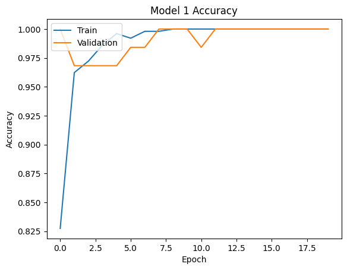

```python
plt.plot(history_model_1.history['accuracy'])
plt.plot(history_model_1.history['val_accuracy'])
plt.title('Model 1 Accuracy')
plt.ylabel('Accuracy')
plt.xlabel('Epoch')
plt.legend(['Train', 'Validation'], loc='upper left')
plt.show()
```

```python
model_1_train_perf = model_performance_classification(model_1, X_train_rgb_normalized, y_train_encoded)

print("Model 1 Train performance metrics")
print(model_1_train_perf)
```

```
16/16 ━━━━━━━━━━━━━━━━━━━━ 1s 24ms/step
Model 1 Train performance metrics
   Accuracy  Recall  Precision  F1 Score
0       1.0     1.0        1.0       1.0
```

```python
plot_confusion_matrix(model_1, X_train_rgb_normalized, y_train_encoded)
```

[output not shown]

```
16/16 ━━━━━━━━━━━━━━━━━━━━ 0s 20ms/step
```

```python
model_1_valid_perf = model_performance_classification(model_1, X_val_rgb_normalized, y_val_encoded)

print("Model 1 Validation performance metrics")
print(model_1_valid_perf)
```

```
2/2 ━━━━━━━━━━━━━━━━━━━━ 0s 31ms/step
Model 1 Validation performance metrics
   Accuracy  Recall  Precision  F1 Score
0       1.0     1.0        1.0       1.0
```

```python
plot_confusion_matrix(model_1, X_val_rgb_normalized, y_val_encoded)
```

[output not shown]

```
2/2 ━━━━━━━━━━━━━━━━━━━━ 0s 32ms/step
```

- The model has achieved approximately 100% accuracy on the training set and validation set.

#### Visualizing the prediction:

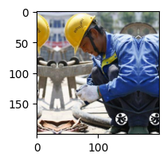

```
1/1 ━━━━━━━━━━━━━━━━━━━━ 0s 39ms/step
Predicted Label [1]
True Label 1
```

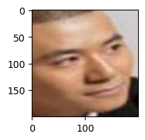

```
1/1 ━━━━━━━━━━━━━━━━━━━━ 0s 37ms/step
Predicted Label [0]
True Label 0
```

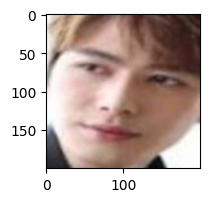

```
1/1 ━━━━━━━━━━━━━━━━━━━━ 0s 37ms/step
Predicted Label [0]
True Label 0
```

```python
# Visualizing the predicted and correct label of images from validation data
plt.figure(figsize=(2,2))
plt.imshow(X_val_rgb[3])
plt.show()
print('Predicted Label', enc.inverse_transform(model_1.predict((X_val_rgb_normalized[3].reshape(1,200,200,3)))))
print('True Label', enc.inverse_transform(y_val_encoded)[3])

plt.figure(figsize=(2,2))
plt.imshow(X_val_rgb[55])
plt.show()
print('Predicted Label', enc.inverse_transform(model_1.predict((X_val_rgb_normalized[55].reshape(1,200,200,3)))))
print('True Label', enc.inverse_transform(y_val_encoded)[55])

plt.figure(figsize=(2,2))
plt.imshow(X_val_rgb[44])
plt.show()
print('Predicted Label', enc.inverse_transform(model_1.predict((X_val_rgb_normalized[44].reshape(1,200,200,3)))))
print('True Label', enc.inverse_transform(y_val_encoded)[44])
```

## Model 2: (VGG-16 (Base))

- We will be loading a pre-built architecture - **VGG16**, which was trained on the ImageNet dataset and is the runner-up in the ImageNet competition in 2014.
- For training VGG16, we will directly use the convolutional and pooling layers and freeze their weights i.e. no training will be done on them. For classification, we will add a Flatten and a single dense layer (output).

```python
vgg_model = VGG16(weights='imagenet',include_top=False,input_shape=(200,200,3))
vgg_model.summary()
```

```
Downloading data from https://storage.googleapis.com/tensorflow/keras-applications/vgg16/vgg16_weights_tf_dim_ordering_tf_kernels_notop.h5
58889256/58889256 ━━━━━━━━━━━━━━━━━━━━ 2s 0us/step
```

```
Model: "vgg16"
```

```
┏━━━━━━━━━━━━━━━━━━━━━━━━━━━━━━━━━┳━━━━━━━━━━━━━━━━━━━━━━━━┳━━━━━━━━━━━━━━━┓
┃ Layer (type)                    ┃ Output Shape           ┃       Param # ┃
┡━━━━━━━━━━━━━━━━━━━━━━━━━━━━━━━━━╇━━━━━━━━━━━━━━━━━━━━━━━━╇━━━━━━━━━━━━━━━┩
│ input_layer_3 (InputLayer)      │ (None, 200, 200, 3)    │             0 │
├─────────────────────────────────┼────────────────────────┼───────────────┤
│ block1_conv1 (Conv2D)           │ (None, 200, 200, 64)   │         1,792 │
├─────────────────────────────────┼────────────────────────┼───────────────┤
│ block1_conv2 (Conv2D)           │ (None, 200, 200, 64)   │        36,928 │
├─────────────────────────────────┼────────────────────────┼───────────────┤
│ block1_pool (MaxPooling2D)      │ (None, 100, 100, 64)   │             0 │
├─────────────────────────────────┼────────────────────────┼───────────────┤
│ block2_conv1 (Conv2D)           │ (None, 100, 100, 128)  │        73,856 │
├─────────────────────────────────┼────────────────────────┼───────────────┤
│ block2_conv2 (Conv2D)           │ (None, 100, 100, 128)  │       147,584 │
├─────────────────────────────────┼────────────────────────┼───────────────┤
│ block2_pool (MaxPooling2D)      │ (None, 50, 50, 128)    │             0 │
├─────────────────────────────────┼────────────────────────┼───────────────┤
│ block3_conv1 (Conv2D)           │ (None, 50, 50, 256)    │       295,168 │
├─────────────────────────────────┼────────────────────────┼───────────────┤
│ block3_conv2 (Conv2D)           │ (None, 50, 50, 256)    │       590,080 │
├─────────────────────────────────┼────────────────────────┼───────────────┤
│ block3_conv3 (Conv2D)           │ (None, 50, 50, 256)    │       590,080 │
├─────────────────────────────────┼────────────────────────┼───────────────┤
│ block3_pool (MaxPooling2D)      │ (None, 25, 25, 256)    │             0 │
├─────────────────────────────────┼────────────────────────┼───────────────┤
│ block4_conv1 (Conv2D)           │ (None, 25, 25, 512)    │     1,180,160 │
├─────────────────────────────────┼────────────────────────┼───────────────┤
│ block4_conv2 (Conv2D)           │ (None, 25, 25, 512)    │     2,359,808 │
├─────────────────────────────────┼────────────────────────┼───────────────┤
│ block4_conv3 (Conv2D)           │ (None, 25, 25, 512)    │     2,359,808 │
├─────────────────────────────────┼────────────────────────┼───────────────┤
│ block4_pool (MaxPooling2D)      │ (None, 12, 12, 512)    │             0 │
├─────────────────────────────────┼────────────────────────┼───────────────┤
│ block5_conv1 (Conv2D)           │ (None, 12, 12, 512)    │     2,359,808 │
├─────────────────────────────────┼────────────────────────┼───────────────┤
│ block5_conv2 (Conv2D)           │ (None, 12, 12, 512)    │     2,359,808 │
├─────────────────────────────────┼────────────────────────┼───────────────┤
│ block5_conv3 (Conv2D)           │ (None, 12, 12, 512)    │     2,359,808 │
├─────────────────────────────────┼────────────────────────┼───────────────┤
│ block5_pool (MaxPooling2D)      │ (None, 6, 6, 512)      │             0 │
└─────────────────────────────────┴────────────────────────┴───────────────┘
```

```
 Total params: 14,714,688 (56.13 MB)
```

```
 Trainable params: 14,714,688 (56.13 MB)
```

```
 Non-trainable params: 0 (0.00 B)
```

```python
# Making all the layers of the VGG model non-trainable. i.e. freezing them
for layer in vgg_model.layers:
    layer.trainable = False
```

```python
model_2 = Sequential()

# Adding the convolutional part of the VGG16 model from above
model_2.add(vgg_model)

# Flattening the output of the VGG16 model because it is from a convolutional layer
model_2.add(Flatten())

# Adding a dense output layer for binary classification
model_2.add(Dense(1, activation='sigmoid'))
```

```python
opt=Adam()
# Compile model
model_2.compile(optimizer=opt, loss='binary_crossentropy', metrics=['accuracy'])
```

```python
# Generating the summary of the model
model_2.summary()
```

```
Model: "sequential_3"
```

```
┏━━━━━━━━━━━━━━━━━━━━━━━━━━━━━━━━━┳━━━━━━━━━━━━━━━━━━━━━━━━┳━━━━━━━━━━━━━━━┓
┃ Layer (type)                    ┃ Output Shape           ┃       Param # ┃
┡━━━━━━━━━━━━━━━━━━━━━━━━━━━━━━━━━╇━━━━━━━━━━━━━━━━━━━━━━━━╇━━━━━━━━━━━━━━━┩
│ vgg16 (Functional)              │ (None, 6, 6, 512)      │    14,714,688 │
├─────────────────────────────────┼────────────────────────┼───────────────┤
│ flatten_3 (Flatten)             │ (None, 18432)          │             0 │
├─────────────────────────────────┼────────────────────────┼───────────────┤
│ dense_6 (Dense)                 │ (None, 1)              │        18,433 │
└─────────────────────────────────┴────────────────────────┴───────────────┘
```

```
 Total params: 14,733,121 (56.20 MB)
```

```
 Trainable params: 18,433 (72.00 KB)
```

```
 Non-trainable params: 14,714,688 (56.13 MB)
```

```python
train_datagen = ImageDataGenerator()
```

```python
# Epochs
epochs = 20
# Batch size
batch_size = 128

history_vgg16 = model_2.fit(train_datagen.flow(X_train_rgb_normalized,y_train_encoded,
                                       batch_size=batch_size,
                                       seed=42,
                                       shuffle=False),
                    epochs=epochs,
                    steps_per_epoch=X_train_rgb_normalized.shape[0] // batch_size,
                    validation_data=(X_val_rgb_normalized,y_val_encoded),
                    verbose=1)
```

```
3/3 ━━━━━━━━━━━━━━━━━━━━ 5s 1s/step - accuracy: 0.6509 - loss: 0.5751 - val_accuracy: 0.9683 - val_loss: 0.2176
3/3 ━━━━━━━━━━━━━━━━━━━━ 1s 125ms/step - accuracy: 0.9844 - loss: 0.1898 - val_accuracy: 0.9683 - val_loss: 0.1757
3/3 ━━━━━━━━━━━━━━━━━━━━ 2s 723ms/step - accuracy: 0.9934 - loss: 0.1066 - val_accuracy: 1.0000 - val_loss: 0.0458
3/3 ━━━━━━━━━━━━━━━━━━━━ 1s 132ms/step - accuracy: 1.0000 - loss: 0.0452 - val_accuracy: 1.0000 - val_loss: 0.0346
3/3 ━━━━━━━━━━━━━━━━━━━━ 2s 729ms/step - accuracy: 0.9973 - loss: 0.0277 - val_accuracy: 1.0000 - val_loss: 0.0197
3/3 ━━━━━━━━━━━━━━━━━━━━ 1s 128ms/step - accuracy: 1.0000 - loss: 0.0153 - val_accuracy: 1.0000 - val_loss: 0.0163
3/3 ━━━━━━━━━━━━━━━━━━━━ 2s 757ms/step - accuracy: 1.0000 - loss: 0.0136 - val_accuracy: 1.0000 - val_loss: 0.0096
3/3 ━━━━━━━━━━━━━━━━━━━━ 1s 138ms/step - accuracy: 1.0000 - loss: 0.0057 - val_accuracy: 1.0000 - val_loss: 0.0083
3/3 ━━━━━━━━━━━━━━━━━━━━ 2s 733ms/step - accuracy: 1.0000 - loss: 0.0057 - val_accuracy: 1.0000 - val_loss: 0.0062
3/3 ━━━━━━━━━━━━━━━━━━━━ 1s 122ms/step - accuracy: 1.0000 - loss: 0.0053 - val_accuracy: 1.0000 - val_loss: 0.0059
3/3 ━━━━━━━━━━━━━━━━━━━━ 2s 741ms/step - accuracy: 1.0000 - loss: 0.0060 - val_accuracy: 1.0000 - val_loss: 0.0055
3/3 ━━━━━━━━━━━━━━━━━━━━ 1s 123ms/step - accuracy: 1.0000 - loss: 0.0034 - val_accuracy: 1.0000 - val_loss: 0.0054
3/3 ━━━━━━━━━━━━━━━━━━━━ 2s 753ms/step - accuracy: 1.0000 - loss: 0.0042 - val_accuracy: 1.0000 - val_loss: 0.0050
3/3 ━━━━━━━━━━━━━━━━━━━━ 1s 124ms/step - accuracy: 1.0000 - loss: 0.0016 - val_accuracy: 1.0000 - val_loss: 0.0049
3/3 ━━━━━━━━━━━━━━━━━━━━ 2s 734ms/step - accuracy: 1.0000 - loss: 0.0024 - val_accuracy: 1.0000 - val_loss: 0.0044
3/3 ━━━━━━━━━━━━━━━━━━━━ 1s 171ms/step - accuracy: 1.0000 - loss: 0.0037 - val_accuracy: 1.0000 - val_loss: 0.0042
3/3 ━━━━━━━━━━━━━━━━━━━━ 2s 839ms/step - accuracy: 1.0000 - loss: 0.0027 - val_accuracy: 1.0000 - val_loss: 0.0038
3/3 ━━━━━━━━━━━━━━━━━━━━ 1s 126ms/step - accuracy: 1.0000 - loss: 0.0032 - val_accuracy: 1.0000 - val_loss: 0.0037
3/3 ━━━━━━━━━━━━━━━━━━━━ 3s 970ms/step - accuracy: 1.0000 - loss: 0.0027 - val_accuracy: 1.0000 - val_loss: 0.0032
3/3 ━━━━━━━━━━━━━━━━━━━━ 1s 219ms/step - accuracy: 1.0000 - loss: 0.0018 - val_accuracy: 1.0000 - val_loss: 0.0031
```

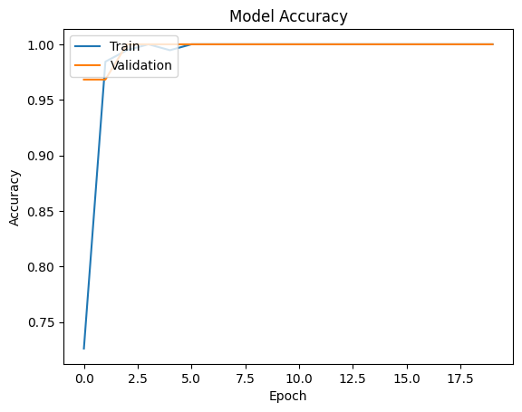

```python
plt.plot(history_vgg16.history['accuracy'])
plt.plot(history_vgg16.history['val_accuracy'])
plt.title('Model Accuracy')
plt.ylabel('Accuracy')
plt.xlabel('Epoch')
plt.legend(['Train', 'Validation'], loc='upper left')
plt.show()
```

```python
model_2_train_perf = model_performance_classification(model_2, X_train_rgb_normalized,y_train_encoded)

print("Train performance metrics")
print(model_2_train_perf)
```

```
16/16 ━━━━━━━━━━━━━━━━━━━━ 2s 123ms/step
Train performance metrics
   Accuracy  Recall  Precision  F1 Score
0       1.0     1.0        1.0       1.0
```

```python
plot_confusion_matrix(model_2,X_train_rgb_normalized,y_train_encoded)
```

[output not shown]

```
16/16 ━━━━━━━━━━━━━━━━━━━━ 2s 110ms/step
```

```python
model_2_valid_perf = model_performance_classification(model_2, X_val_rgb_normalized,y_val_encoded)

print("Validation performance metrics")
print(model_2_valid_perf)
```

```
2/2 ━━━━━━━━━━━━━━━━━━━━ 0s 126ms/step
Validation performance metrics
   Accuracy  Recall  Precision  F1 Score
0       1.0     1.0        1.0       1.0
```

```python
plot_confusion_matrix(model_2,X_val_rgb_normalized,y_val_encoded)
```

[output not shown]

```
2/2 ━━━━━━━━━━━━━━━━━━━━ 0s 134ms/step
```

- The model has achieved approximately 100% accuracy on the training set and validation set.

#### Visualizing the predictions

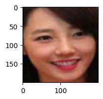

```
1/1 ━━━━━━━━━━━━━━━━━━━━ 0s 70ms/step
Predicted Label [0]
True Label 0
```

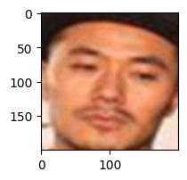

```
1/1 ━━━━━━━━━━━━━━━━━━━━ 0s 68ms/step
Predicted Label [0]
True Label 0
```

[figure not shown]

```
1/1 ━━━━━━━━━━━━━━━━━━━━ 0s 49ms/step
Predicted Label [1]
True Label 1
```

```python
# Visualizing the predicted and correct label of images from test data
plt.figure(figsize=(2,2))
plt.imshow(X_val_rgb[8])
plt.show()
print('Predicted Label', enc.inverse_transform(model_2.predict((X_val_rgb_normalized[8].reshape(1,200,200,3)))))   # reshaping the input image as we are only trying to predict using a single image
print('True Label', enc.inverse_transform(y_val_encoded)[8])                                               # using inverse_transform() to get the output label from the output vector

plt.figure(figsize=(2,2))
plt.imshow(X_val_rgb[11])
plt.show()
print('Predicted Label', enc.inverse_transform(model_2.predict((X_val_rgb_normalized[11].reshape(1,200,200,3)))))  # reshaping the input image as we are only trying to predict using a single image
print('True Label', enc.inverse_transform(y_val_encoded)[11])                                              # using inverse_transform() to get the output label from the output vector

plt.figure(figsize=(2,2))
plt.imshow(X_val_rgb[28])
plt.show()
print('Predicted Label', enc.inverse_transform(model_2.predict((X_val_rgb_normalized[28].reshape(1,200,200,3)))))  # reshaping the input image as we are only trying to predict using a single image
print('True Label', enc.inverse_transform(y_val_encoded)[28])                                              # using inverse_transform() to get the output label from the output vector
```

## Model 3: (VGG-16 (Base + FFNN))

- We will directly use the convolutional and pooling layers (VGG-16) and freeze their weights i.e. no training will be done on them.
- For classification, we will add a Flatten layer and a Feed Forward Neural Network.

```python
model_3 = Sequential()

# Adding the convolutional part of the VGG16 model from above
model_3.add(vgg_model)

# Flattening the output of the VGG16 model because it is from a convolutional layer
model_3.add(Flatten())

#Adding the Feed Forward neural network
model_3.add(Dense(256,activation='relu'))
model_3.add(Dropout(rate=0.4))
model_3.add(Dense(32,activation='relu'))

# Adding a dense output layer
model_3.add(Dense(1, activation='sigmoid'))
```

```python
opt = Adam()
```

```python
# Compile model
model_3.compile(optimizer=opt, loss='binary_crossentropy', metrics=['accuracy'])
```

```python
# Generating the summary of the model
model_3.summary()
```

```
Model: "sequential_4"
```

```
┏━━━━━━━━━━━━━━━━━━━━━━━━━━━━━━━━━┳━━━━━━━━━━━━━━━━━━━━━━━━┳━━━━━━━━━━━━━━━┓
┃ Layer (type)                    ┃ Output Shape           ┃       Param # ┃
┡━━━━━━━━━━━━━━━━━━━━━━━━━━━━━━━━━╇━━━━━━━━━━━━━━━━━━━━━━━━╇━━━━━━━━━━━━━━━┩
│ vgg16 (Functional)              │ (None, 6, 6, 512)      │    14,714,688 │
├─────────────────────────────────┼────────────────────────┼───────────────┤
│ flatten_4 (Flatten)             │ (None, 18432)          │             0 │
├─────────────────────────────────┼────────────────────────┼───────────────┤
│ dense_7 (Dense)                 │ (None, 256)            │     4,718,848 │
├─────────────────────────────────┼────────────────────────┼───────────────┤
│ dropout (Dropout)               │ (None, 256)            │             0 │
├─────────────────────────────────┼────────────────────────┼───────────────┤
│ dense_8 (Dense)                 │ (None, 32)             │         8,224 │
├─────────────────────────────────┼────────────────────────┼───────────────┤
│ dense_9 (Dense)                 │ (None, 1)              │            33 │
└─────────────────────────────────┴────────────────────────┴───────────────┘
```

```
 Total params: 19,441,793 (74.16 MB)
```

```
 Trainable params: 4,727,105 (18.03 MB)
```

```
 Non-trainable params: 14,714,688 (56.13 MB)
```

```python
history_vgg16 = model_3.fit(train_datagen.flow(X_train_rgb_normalized,y_train_encoded,
                                       batch_size=batch_size,
                                       seed=42,
                                       shuffle=False),
                    epochs=epochs,
                    steps_per_epoch=X_train_rgb_normalized.shape[0] // batch_size,
                    validation_data=(X_val_rgb_normalized,y_val_encoded),
                    verbose=1)
```

```
3/3 ━━━━━━━━━━━━━━━━━━━━ 5s 1s/step - accuracy: 0.6266 - loss: 0.7721 - val_accuracy: 1.0000 - val_loss: 0.0037
3/3 ━━━━━━━━━━━━━━━━━━━━ 1s 142ms/step - accuracy: 0.9844 - loss: 0.0242 - val_accuracy: 0.8413 - val_loss: 0.3744
3/3 ━━━━━━━━━━━━━━━━━━━━ 2s 729ms/step - accuracy: 0.9165 - loss: 0.2667 - val_accuracy: 1.0000 - val_loss: 9.8535e-04
3/3 ━━━━━━━━━━━━━━━━━━━━ 1s 123ms/step - accuracy: 0.9922 - loss: 0.0371 - val_accuracy: 1.0000 - val_loss: 3.2620e-05
3/3 ━━━━━━━━━━━━━━━━━━━━ 2s 743ms/step - accuracy: 1.0000 - loss: 6.1307e-04 - val_accuracy: 1.0000 - val_loss: 2.0319e-04
3/3 ━━━━━━━━━━━━━━━━━━━━ 1s 124ms/step - accuracy: 0.9844 - loss: 0.0473 - val_accuracy: 1.0000 - val_loss: 3.0860e-04
3/3 ━━━━━━━━━━━━━━━━━━━━ 2s 742ms/step - accuracy: 0.9931 - loss: 0.0435 - val_accuracy: 1.0000 - val_loss: 6.4987e-05
3/3 ━━━━━━━━━━━━━━━━━━━━ 1s 124ms/step - accuracy: 1.0000 - loss: 9.8094e-04 - val_accuracy: 1.0000 - val_loss: 2.3656e-05
3/3 ━━━━━━━━━━━━━━━━━━━━ 2s 765ms/step - accuracy: 0.9987 - loss: 0.0048 - val_accuracy: 1.0000 - val_loss: 1.1599e-06
3/3 ━━━━━━━━━━━━━━━━━━━━ 1s 135ms/step - accuracy: 1.0000 - loss: 1.2205e-04 - val_accuracy: 1.0000 - val_loss: 4.0661e-07
3/3 ━━━━━━━━━━━━━━━━━━━━ 2s 761ms/step - accuracy: 0.9957 - loss: 0.0167 - val_accuracy: 1.0000 - val_loss: 3.4747e-08
3/3 ━━━━━━━━━━━━━━━━━━━━ 1s 126ms/step - accuracy: 1.0000 - loss: 1.0750e-05 - val_accuracy: 1.0000 - val_loss: 3.6035e-08
3/3 ━━━━━━━━━━━━━━━━━━━━ 2s 781ms/step - accuracy: 1.0000 - loss: 2.6344e-04 - val_accuracy: 1.0000 - val_loss: 7.5702e-08
3/3 ━━━━━━━━━━━━━━━━━━━━ 1s 126ms/step - accuracy: 1.0000 - loss: 5.5092e-05 - val_accuracy: 1.0000 - val_loss: 9.7149e-08
3/3 ━━━━━━━━━━━━━━━━━━━━ 2s 760ms/step - accuracy: 1.0000 - loss: 2.1055e-06 - val_accuracy: 1.0000 - val_loss: 1.8313e-07
3/3 ━━━━━━━━━━━━━━━━━━━━ 1s 128ms/step - accuracy: 1.0000 - loss: 1.3387e-04 - val_accuracy: 1.0000 - val_loss: 2.1979e-07
3/3 ━━━━━━━━━━━━━━━━━━━━ 2s 783ms/step - accuracy: 0.9987 - loss: 0.0079 - val_accuracy: 1.0000 - val_loss: 2.3861e-07
3/3 ━━━━━━━━━━━━━━━━━━━━ 1s 135ms/step - accuracy: 1.0000 - loss: 1.7436e-05 - val_accuracy: 1.0000 - val_loss: 1.9288e-07
3/3 ━━━━━━━━━━━━━━━━━━━━ 2s 799ms/step - accuracy: 0.9956 - loss: 0.0124 - val_accuracy: 1.0000 - val_loss: 5.0437e-08
3/3 ━━━━━━━━━━━━━━━━━━━━ 1s 127ms/step - accuracy: 1.0000 - loss: 5.4767e-08 - val_accuracy: 1.0000 - val_loss: 3.5303e-08
```

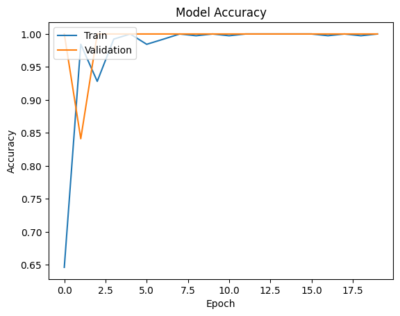

```python
plt.plot(history_vgg16.history['accuracy'])
plt.plot(history_vgg16.history['val_accuracy'])
plt.title('Model Accuracy')
plt.ylabel('Accuracy')
plt.xlabel('Epoch')
plt.legend(['Train', 'Validation'], loc='upper left')
plt.show()
```

```python
model_3_train_perf = model_performance_classification(model_3, X_train_rgb_normalized,y_train_encoded)

print("Train performance metrics")
print(model_3_train_perf)
```

```
16/16 ━━━━━━━━━━━━━━━━━━━━ 2s 119ms/step
Train performance metrics
   Accuracy  Recall  Precision  F1 Score
0       1.0     1.0        1.0       1.0
```

```python
plot_confusion_matrix(model_3,X_train_rgb_normalized,y_train_encoded)
```

[output not shown]

```
16/16 ━━━━━━━━━━━━━━━━━━━━ 2s 112ms/step
```

```python
model_3_valid_perf = model_performance_classification(model_3, X_val_rgb_normalized,y_val_encoded)

print("Validation performance metrics")
print(model_3_valid_perf)
```

```
2/2 ━━━━━━━━━━━━━━━━━━━━ 0s 122ms/step
Validation performance metrics
   Accuracy  Recall  Precision  F1 Score
0       1.0     1.0        1.0       1.0
```

```python
plot_confusion_matrix(model_3,X_val_rgb_normalized,y_val_encoded)
```

[output not shown]

```
2/2 ━━━━━━━━━━━━━━━━━━━━ 0s 122ms/step
```

- The model has achieved approximately 100% accuracy on the training set and validation set.

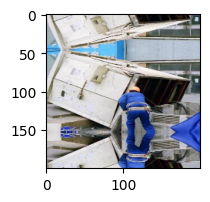

```
1/1 ━━━━━━━━━━━━━━━━━━━━ 0s 66ms/step
Predicted Label [1]
True Label 1
```

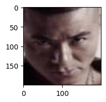

```
1/1 ━━━━━━━━━━━━━━━━━━━━ 0s 76ms/step
Predicted Label [0]
True Label 0
```

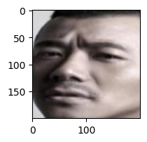

```
1/1 ━━━━━━━━━━━━━━━━━━━━ 0s 64ms/step
Predicted Label [0]
True Label 0
```

```python
# Visualizing the predicted and correct label of images from test data
plt.figure(figsize=(2,2))
plt.imshow(X_val_rgb[21])
plt.show()
print('Predicted Label', enc.inverse_transform(model_2.predict((X_val_rgb_normalized[21].reshape(1,200,200,3)))))   # reshaping the input image as we are only trying to predict using a single image
print('True Label', enc.inverse_transform(y_val_encoded)[21])                                               # using inverse_transform() to get the output label from the output vector

plt.figure(figsize=(2,2))
plt.imshow(X_val_rgb[18])
plt.show()
print('Predicted Label', enc.inverse_transform(model_2.predict((X_val_rgb_normalized[18].reshape(1,200,200,3)))))  # reshaping the input image as we are only trying to predict using a single image
print('True Label', enc.inverse_transform(y_val_encoded)[18])                                              # using inverse_transform() to get the output label from the output vector

plt.figure(figsize=(2,2))
plt.imshow(X_val_rgb[54])
plt.show()
print('Predicted Label', enc.inverse_transform(model_2.predict((X_val_rgb_normalized[54].reshape(1,200,200,3)))))  # reshaping the input image as we are only trying to predict using a single image
print('True Label', enc.inverse_transform(y_val_encoded)[54])                                              # using inverse_transform() to get the output label from the output vector
```

## Model 4: (VGG-16 (Base + FFNN + Data Augmentation)

- In most of the real-world case studies, it is challenging to acquire a large number of images and then train CNNs.
- To overcome this problem, one approach we might consider is **Data Augmentation**.
- CNNs have the property of **translational invariance**, which means they can recognise an object even if its appearance shifts translationally in some way. - Taking this attribute into account, we can augment the images using the techniques listed below
  - Horizontal Flip (should be set to True/False)
  - Vertical Flip (should be set to True/False)
  - Height Shift (should be between 0 and 1)
  - Width Shift (should be between 0 and 1)
  - Rotation (should be between 0 and 180)
  - Shear (should be between 0 and 1)
  - Zoom (should be between 0 and 1) etc.

Remember, **data augmentation should not be used in the validation/test data set**.

```python
model_4 = Sequential()

# Adding the convolutional part of the VGG16 model from above
model_4.add(vgg_model)

# Flattening the output of the VGG16 model because it is from a convolutional layer
model_4.add(Flatten())

#Adding the Feed Forward neural network
model_4.add(Dense(256,activation='relu'))
model_4.add(Dropout(rate=0.4))
model_4.add(Dense(32,activation='relu'))

# Adding a dense output layer
model_4.add(Dense(1, activation='sigmoid'))
```

```python
opt=Adam()
# Compile model
model_4.compile(optimizer=opt, loss='binary_crossentropy', metrics=['accuracy'])
```

```python
# Generating the summary of the model
model_4.summary()
```

```
Model: "sequential_5"
```

```
┏━━━━━━━━━━━━━━━━━━━━━━━━━━━━━━━━━┳━━━━━━━━━━━━━━━━━━━━━━━━┳━━━━━━━━━━━━━━━┓
┃ Layer (type)                    ┃ Output Shape           ┃       Param # ┃
┡━━━━━━━━━━━━━━━━━━━━━━━━━━━━━━━━━╇━━━━━━━━━━━━━━━━━━━━━━━━╇━━━━━━━━━━━━━━━┩
│ vgg16 (Functional)              │ (None, 6, 6, 512)      │    14,714,688 │
├─────────────────────────────────┼────────────────────────┼───────────────┤
│ flatten_5 (Flatten)             │ (None, 18432)          │             0 │
├─────────────────────────────────┼────────────────────────┼───────────────┤
│ dense_10 (Dense)                │ (None, 256)            │     4,718,848 │
├─────────────────────────────────┼────────────────────────┼───────────────┤
│ dropout_1 (Dropout)             │ (None, 256)            │             0 │
├─────────────────────────────────┼────────────────────────┼───────────────┤
│ dense_11 (Dense)                │ (None, 32)             │         8,224 │
├─────────────────────────────────┼────────────────────────┼───────────────┤
│ dense_12 (Dense)                │ (None, 1)              │            33 │
└─────────────────────────────────┴────────────────────────┴───────────────┘
```

```
 Total params: 19,441,793 (74.16 MB)
```

```
 Trainable params: 4,727,105 (18.03 MB)
```

```
 Non-trainable params: 14,714,688 (56.13 MB)
```

```python
# Applying data augmentation
train_datagen = ImageDataGenerator(
                              rotation_range=20,
                              fill_mode='nearest',
                              width_shift_range=0.2,
                              height_shift_range=0.2,
                              shear_range=0.3,
                              zoom_range=0.4
                              )
```

```python
history_vgg16 = model_4.fit(train_datagen.flow(X_train_rgb_normalized,y_train_encoded,
                                       batch_size=batch_size,
                                       seed=42,
                                       shuffle=False),
                    epochs=epochs,
                    steps_per_epoch=X_train_rgb_normalized.shape[0] // batch_size,
                    validation_data=(X_val_rgb_normalized,y_val_encoded),
                    verbose=1)
```

```
3/3 ━━━━━━━━━━━━━━━━━━━━ 8s 2s/step - accuracy: 0.4730 - loss: 1.0377 - val_accuracy: 0.4921 - val_loss: 0.7201
3/3 ━━━━━━━━━━━━━━━━━━━━ 2s 124ms/step - accuracy: 0.5750 - loss: 0.7717 - val_accuracy: 0.9841 - val_loss: 0.0921
3/3 ━━━━━━━━━━━━━━━━━━━━ 5s 2s/step - accuracy: 0.9287 - loss: 0.2031 - val_accuracy: 0.9841 - val_loss: 0.0441
3/3 ━━━━━━━━━━━━━━━━━━━━ 2s 127ms/step - accuracy: 0.9417 - loss: 0.1031 - val_accuracy: 1.0000 - val_loss: 0.0063
3/3 ━━━━━━━━━━━━━━━━━━━━ 6s 2s/step - accuracy: 0.9747 - loss: 0.0740 - val_accuracy: 1.0000 - val_loss: 8.2491e-04
3/3 ━━━━━━━━━━━━━━━━━━━━ 2s 126ms/step - accuracy: 0.9688 - loss: 0.1236 - val_accuracy: 1.0000 - val_loss: 5.4147e-04
3/3 ━━━━━━━━━━━━━━━━━━━━ 5s 2s/step - accuracy: 0.9699 - loss: 0.1096 - val_accuracy: 1.0000 - val_loss: 1.4037e-04
3/3 ━━━━━━━━━━━━━━━━━━━━ 2s 141ms/step - accuracy: 1.0000 - loss: 0.0063 - val_accuracy: 1.0000 - val_loss: 3.2421e-04
3/3 ━━━━━━━━━━━━━━━━━━━━ 6s 2s/step - accuracy: 0.9896 - loss: 0.0273 - val_accuracy: 1.0000 - val_loss: 0.0011
3/3 ━━━━━━━━━━━━━━━━━━━━ 2s 139ms/step - accuracy: 0.9688 - loss: 0.1077 - val_accuracy: 1.0000 - val_loss: 8.1008e-04
3/3 ━━━━━━━━━━━━━━━━━━━━ 5s 2s/step - accuracy: 0.9831 - loss: 0.0309 - val_accuracy: 1.0000 - val_loss: 8.4336e-05
3/3 ━━━━━━━━━━━━━━━━━━━━ 3s 142ms/step - accuracy: 1.0000 - loss: 0.0042 - val_accuracy: 1.0000 - val_loss: 4.2180e-05
3/3 ━━━━━━━━━━━━━━━━━━━━ 5s 2s/step - accuracy: 0.9987 - loss: 0.0101 - val_accuracy: 1.0000 - val_loss: 6.8439e-06
3/3 ━━━━━━━━━━━━━━━━━━━━ 2s 129ms/step - accuracy: 1.0000 - loss: 0.0017 - val_accuracy: 1.0000 - val_loss: 4.3845e-06
3/3 ━━━━━━━━━━━━━━━━━━━━ 6s 2s/step - accuracy: 0.9956 - loss: 0.0105 - val_accuracy: 1.0000 - val_loss: 1.1851e-06
3/3 ━━━━━━━━━━━━━━━━━━━━ 2s 132ms/step - accuracy: 1.0000 - loss: 0.0013 - val_accuracy: 1.0000 - val_loss: 9.9271e-07
3/3 ━━━━━━━━━━━━━━━━━━━━ 5s 2s/step - accuracy: 0.9950 - loss: 0.0067 - val_accuracy: 1.0000 - val_loss: 7.8919e-07
3/3 ━━━━━━━━━━━━━━━━━━━━ 2s 127ms/step - accuracy: 1.0000 - loss: 0.0046 - val_accuracy: 1.0000 - val_loss: 7.9377e-07
3/3 ━━━━━━━━━━━━━━━━━━━━ 6s 2s/step - accuracy: 0.9964 - loss: 0.0088 - val_accuracy: 1.0000 - val_loss: 8.0609e-07
3/3 ━━━━━━━━━━━━━━━━━━━━ 2s 126ms/step - accuracy: 0.9922 - loss: 0.0354 - val_accuracy: 1.0000 - val_loss: 8.2639e-07
```

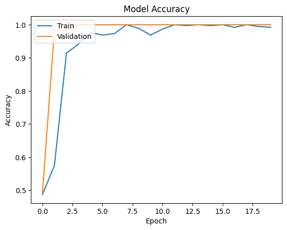

```python
plt.plot(history_vgg16.history['accuracy'])
plt.plot(history_vgg16.history['val_accuracy'])
plt.title('Model Accuracy')
plt.ylabel('Accuracy')
plt.xlabel('Epoch')
plt.legend(['Train', 'Validation'], loc='upper left')
plt.show()
```

```python
model_4_train_perf = model_performance_classification(model_4, X_train_rgb_normalized,y_train_encoded)

print("Train performance metrics")
print(model_4_train_perf)
```

```
16/16 ━━━━━━━━━━━━━━━━━━━━ 3s 123ms/step
Train performance metrics
   Accuracy  Recall  Precision  F1 Score
0       1.0     1.0        1.0       1.0
```

```python
plot_confusion_matrix(model_4,X_train_rgb_normalized,y_train_encoded)
```

[output not shown]

```
16/16 ━━━━━━━━━━━━━━━━━━━━ 2s 112ms/step
```

```python
model_4_valid_perf = model_performance_classification(model_4, X_val_rgb_normalized,y_val_encoded)

print("Validation performance metrics")
print(model_4_valid_perf)
```

```
2/2 ━━━━━━━━━━━━━━━━━━━━ 0s 134ms/step
Validation performance metrics
   Accuracy  Recall  Precision  F1 Score
0       1.0     1.0        1.0       1.0
```

```python
plot_confusion_matrix(model_4,X_val_rgb_normalized,y_val_encoded)
```

[output not shown]

```
2/2 ━━━━━━━━━━━━━━━━━━━━ 0s 123ms/step
```

- The model has achieved approximately 100% accuracy on the training set and the validation set.

#### Visualizing the prediction:

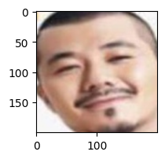

```
1/1 ━━━━━━━━━━━━━━━━━━━━ 0s 42ms/step
Predicted Label [0]
True Label 0
```

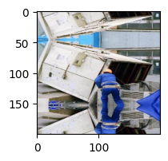

```
1/1 ━━━━━━━━━━━━━━━━━━━━ 0s 45ms/step
Predicted Label [1]
True Label 1
```

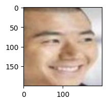

```
1/1 ━━━━━━━━━━━━━━━━━━━━ 0s 42ms/step
Predicted Label [0]
True Label 0
```

```python
# Visualizing the predicted and correct label of images from test data
plt.figure(figsize=(2,2))
plt.imshow(X_val_rgb[2])
plt.show()
print('Predicted Label', enc.inverse_transform(model_4.predict((X_val_rgb_normalized[2].reshape(1,200,200,3)))))   # reshaping the input image as we are only trying to predict using a single image
print('True Label', enc.inverse_transform(y_val_encoded)[2])                                               # using inverse_transform() to get the output label from the output vector

plt.figure(figsize=(2,2))
plt.imshow(X_val_rgb[21])
plt.show()
print('Predicted Label', enc.inverse_transform(model_4.predict((X_val_rgb_normalized[21].reshape(1,200,200,3)))))  # reshaping the input image as we are only trying to predict using a single image
print('True Label', enc.inverse_transform(y_val_encoded)[21])                                              # using inverse_transform() to get the output label from the output vector

plt.figure(figsize=(2,2))
plt.imshow(X_val_rgb[36])
plt.show()
print('Predicted Label', enc.inverse_transform(model_4.predict((X_val_rgb_normalized[36].reshape(1,200,200,3)))))  # reshaping the input image as we are only trying to predict using a single image
print('True Label', enc.inverse_transform(y_val_encoded)[36])                                              # using inverse_transform() to get the output label from the output vector
```

# **Model Performance Comparison and Final Model Selection**

```python
# training performance comparison

models_train_comp_df = pd.concat(
    [
        model_1_train_perf.T,
        model_2_train_perf.T,
        model_3_train_perf.T,
        model_4_train_perf.T,
    ],
    axis=1,
)
models_train_comp_df.columns = [
    "Simple CNN","VGG-16 (Base)","VGG-16 (Base+FFNN)","VGG-16 (Base+FFNN+Data Aug)"
]
```

```python
models_valid_comp_df = pd.concat(
    [
        model_1_valid_perf.T,
        model_2_valid_perf.T,
        model_3_valid_perf.T,
        model_4_train_perf.T,
    ],
    axis=1,
)
models_valid_comp_df.columns = [
 "Simple CNN","VGG-16 (Base)","VGG-16 (Base+FFNN)","VGG-16 (Base+FFNN+Data Aug)"
]
```

```python
models_train_comp_df
```

|  | Simple CNN | VGG-16 (Base) | VGG-16 (Base+FFNN) | VGG-16 (Base+FFNN+Data Aug) |
| --- | --- | --- | --- | --- |
| Accuracy | 1.0 | 1.0 | 1.0 | 1.0 |
| Recall | 1.0 | 1.0 | 1.0 | 1.0 |
| Precision | 1.0 | 1.0 | 1.0 | 1.0 |
| F1 Score | 1.0 | 1.0 | 1.0 | 1.0 |

```python
models_valid_comp_df
```

[output not shown]

```python
models_train_comp_df - models_valid_comp_df
```

|  | Simple CNN | VGG-16 (Base) | VGG-16 (Base+FFNN) | VGG-16 (Base+FFNN+Data Aug) |
| --- | --- | --- | --- | --- |
| Accuracy | 0.0 | 0.0 | 0.0 | 0.0 |
| Recall | 0.0 | 0.0 | 0.0 | 0.0 |
| Precision | 0.0 | 0.0 | 0.0 | 0.0 |
| F1 Score | 0.0 | 0.0 | 0.0 | 0.0 |

- since all the models have shwon perfect score, let's evaluate their performance on test data

### Test Performance

#### Test Performance on model 1

```python
model_1_test_perf = model_performance_classification(model_1, X_test_rgb_normalized,y_test_encoded)
```

```
2/2 ━━━━━━━━━━━━━━━━━━━━ 0s 28ms/step
```

```python
model_1_test_perf
```

|  | Accuracy | Recall | Precision | F1 Score |
| --- | --- | --- | --- | --- |
| 0 | 1.0 | 1.0 | 1.0 | 1.0 |

```python
plot_confusion_matrix(model_1, X_test_rgb_normalized,y_test_encoded)
```

[output not shown]

```
2/2 ━━━━━━━━━━━━━━━━━━━━ 0s 28ms/step
```

#### Test Performance on Model 2

```python
model_2_test_perf = model_performance_classification(model_2, X_test_rgb_normalized,y_test_encoded)
```

```
2/2 ━━━━━━━━━━━━━━━━━━━━ 0s 147ms/step
```

```python
model_2_test_perf
```

|  | Accuracy | Recall | Precision | F1 Score |
| --- | --- | --- | --- | --- |
| 0 | 1.0 | 1.0 | 1.0 | 1.0 |

```python
plot_confusion_matrix(model_2, X_test_rgb_normalized,y_test_encoded)
```

[output not shown]

```
2/2 ━━━━━━━━━━━━━━━━━━━━ 0s 114ms/step
```

#### Test Performance on model 3

```python
model_3_test_perf = model_performance_classification(model_3, X_test_rgb_normalized,y_test_encoded)
```

```
2/2 ━━━━━━━━━━━━━━━━━━━━ 0s 115ms/step
```

```python
model_3_test_perf
```

|  | Accuracy | Recall | Precision | F1 Score |
| --- | --- | --- | --- | --- |
| 0 | 1.0 | 1.0 | 1.0 | 1.0 |

```python
plot_confusion_matrix(model_3, X_test_rgb_normalized,y_test_encoded)
```

[output not shown]

```
2/2 ━━━━━━━━━━━━━━━━━━━━ 0s 115ms/step
```

#### Test Performance on model 4

```python
model_4_test_perf = model_performance_classification(model_4, X_test_rgb_normalized,y_test_encoded)
```

```
2/2 ━━━━━━━━━━━━━━━━━━━━ 0s 115ms/step
```

```python
model_4_test_perf
```

|  | Accuracy | Recall | Precision | F1 Score |
| --- | --- | --- | --- | --- |
| 0 | 1.0 | 1.0 | 1.0 | 1.0 |

```python
plot_confusion_matrix(model_4, X_test_rgb_normalized,y_test_encoded)
```

[output not shown]

```
2/2 ━━━━━━━━━━━━━━━━━━━━ 0s 122ms/step
```

- **All metrics = 1.0** - Model has truly learned perfect separation. Rare but possible.
- **Dataset ≈ 630 images total** - Very small dataset — easy for CNNs to memorize pixel patterns. Even the validation/test splits may be too similar (e.g., nearly identical images of the same subject).
- **No label noise or class imbalance** - Perfect recall/precision suggest the dataset is extremely clean and separable.

# **Actionable Insights & Recommendations**

### Insights

- **All metrics = 1.0** - Model has truly learned perfect separation. Rare but possible.
- **Dataset ≈ 630 images total** - Very small dataset — easy for CNNs to memorize pixel patterns. Even the validation/test splits may be too similar (e.g., nearly identical images of the same subject).
- Model sees same patterns in training and test — artificially inflates accuracy. Very common.
- **No label noise or class imbalance** - Perfect recall/precision suggest the dataset is extremely clean and separable.

### Recommendations

- These models can be further improved by training with different filter sizes and different number of filters.
- Data Augmentation can be performed more and dropout_rate can be changed to improve the model performance.
- Other Transfer Learning architectures can also be used to train the CNN model and these models can be used for classification.

Power Ahead!